# Building a model from BUGS code in R using NIMBLE

The BUGS language for declaring statistical models was popularized by [WinBUGS](http://www.mrc-bsu.cam.ac.uk/software/bugs/), [OpenBUGS](http://www.openbugs.net/w/FrontPage) and [JAGS](http://mcmc-jags.sourceforge.net/). Those generate and run an MCMC for the model, but they don’t allow a programmer to use the model in any other way. NIMBLE provides a new implementation of the BUGS language and creates model objects you can program with.

NIMBLE supports most models written for BUGS or JAGS. It also extends the BUGS language in a bunch of ways that we won’t go into here. See the [User Manual](https://r-nimble.org/html_manual/cha-welcome-nimble.html) for more details.

## Dyes example

Let’s pick a simple model from the classic WinBUGS examples: the dyes example. This is a simple normal hierarchical model. A description can be found [here](http://www.mrc-bsu.cam.ac.uk/wp-content/uploads/WinBUGS_Vol1.pdf). A copy of the original is on our GitHub repository [here](https://github.com/nimble-dev/nimble/tree/devel/packages/nimble/inst/classic-bugs/vol1/dyes). A modified version we will use is set up like this:

```r
library(nimble, warn.conflicts = FALSE)
dyesCode <- nimbleCode({
# Model
   for (i in 1:BATCHES) {
      for (j in 1:SAMPLES) {
         y[i,j] ~ dnorm(mu[i], sd = sigma.within);
      }
      mu[i] ~ dnorm(theta, sd = sigma.between);
   }

# Priors
   theta ~ dnorm(0.0, 1.0E-10);
   sigma.within ~ dunif(0, 100)
   sigma.between ~ dunif(0, 100)
})
```

Compared to the original, this has been modified by using standard deviation parameters instead of precision parameters in two places – to illustrate NIMBLE’s ability to handle different parameterizations – and by removing the posterior predictive nodes.

By the way, any of the standard WinBUGS examples can be loaded automatically in NIMBLE like this:

```
classicDyesModel <- readBUGSmodel('dyes', dir = getBUGSexampleDir('dyes'))
```

## Create the model

We can create a model from `dyesCode` like this:

```r
dyesModel <- nimbleModel(dyesCode, constants = list(BATCHES = 6, SAMPLES = 5))
```

```
## Defining model
```

```
## Building model
```

```
## Running calculate on model
##   [Note] Any error reports that follow may simply reflect missing values in model variables.
```

```
## Checking model sizes and dimensions
```

```
##   [Note] This model is not fully initialized. This is not an error.
##          To see which variables are not initialized, use model$initializeInfo().
##          For more information on model initialization, see help(modelInitialization).
```

And we can set data values in it like this:

```r
data <- matrix(c(1545, 1540, 1595, 1445, 1595, 1520, 1440, 1555, 1550,
1440, 1630, 1455, 1440, 1490, 1605, 1595, 1515, 1450, 1520, 1560,
1510, 1465, 1635, 1480, 1580, 1495, 1560, 1545, 1625, 1445), nrow = 6)

dyesModel$setData(list(y = data))
dyesModel$y
```

```
##      [,1] [,2] [,3] [,4] [,5]
## [1,] 1545 1440 1440 1520 1580
## [2,] 1540 1555 1490 1560 1495
## [3,] 1595 1550 1605 1510 1560
## [4,] 1445 1440 1595 1465 1545
## [5,] 1595 1630 1515 1635 1625
## [6,] 1520 1455 1450 1480 1445
```

It is also possible to set data values when calling `nimbleModel`.

## Use the model

Now the model is an R object, and we can manipulate it as such.

### Set or get values

```r
dyesModel$theta <- 1500
dyesModel$mu <- rnorm(6, 1500, 50)
dyesModel$sigma.within <- 20
dyesModel$sigma.between <- 20
dyesModel$y[1,]
```

```
## [1] 1545 1440 1440 1520 1580
```

```r
dyesModel$theta
```

```
## [1] 1500
```

### Calculate log probability densities for part or all of the model

```r
## arbitrary example
dyesModel$calculate(c('theta', 'mu[1:6]', 'y[,2]'))
```

```
## [1] -108.8983
```

### Simulate part or all of the model

```r
## arbitrary example
dyesModel$mu
```

```
## [1] 1502.355 1513.561 1547.791 1451.070 1541.609 1573.508
```

```r
dyesModel$simulate(c('mu[1:3]'))
dyesModel$mu
```

```
## [1] 1487.869 1496.010 1508.519 1451.070 1541.609 1573.508
```

### Query the model’s relationships

```r
## arbitrary example
dyesModel$getDependencies(c('theta', 'mu[3]'))
```

```
##  [1] "theta"   "mu[1]"   "mu[2]"   "mu[3]"   "mu[4]"   "mu[5]"   "mu[6]"
##  [8] "y[3, 1]" "y[3, 2]" "y[3, 3]" "y[3, 4]" "y[3, 5]"
```

### Plot the model graph (thanks to igraph’s plot feature)

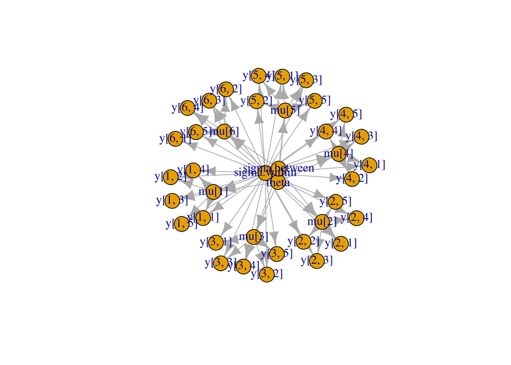

```r
library(igraph)
plot(dyesModel$getGraph())
```

## Compile the model

Finally we can compile the model and use the compiled version the same way we used the uncompiled version above:

```r
compiled_dyesModel <- compileNimble(dyesModel)
```

```
## Compiling
##   [Note] This may take a minute.
##   [Note] Use 'showCompilerOutput = TRUE' to see C++ compilation details.
```

```r
compiled_dyesModel$theta <- 1450
compiled_dyesModel$calculate() ## all nodes by default
```

```
## [1] -403.8924
```

Naturally, the compiled version is much faster.